# Juli:Menstrual Cycle & Mood Analysis

# Data Cleaning

Data cleaning ensures:

- All users are 18 and above.
- Reduces data set to users with Menstrual Cycle (MC) data and dates
- Date variables are in Date Format.

## Data Transformation

We created an algorithm to determine the how the finding date of each observation related to a period date.

To do this we create a variable, ‘cycle day’ and limited it to the range -14 to 21.

After the transformation we found that 160,787 (72%), of the observations were not within -14 or +21 days of a period, therefore we dropped these observations.

This reduced the data set to 60,363 observations with 2691 users.

## Transform Outcome Variable

We transformed the outcome variable, mood, to be measured as a relative measure as a distance from each users mean.

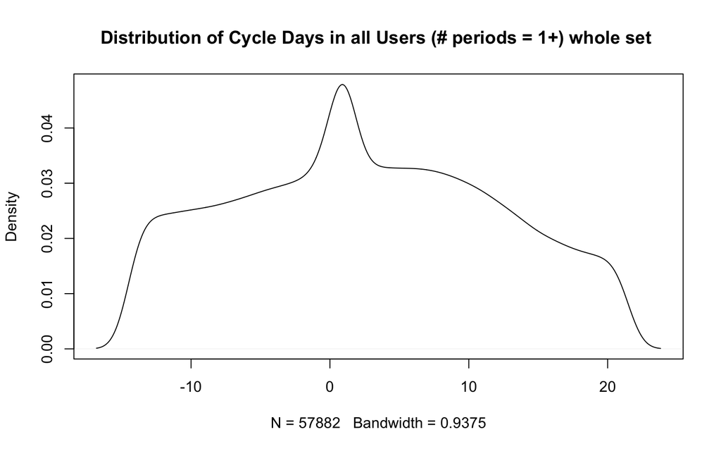

## Reduce data set to only who has measured mood

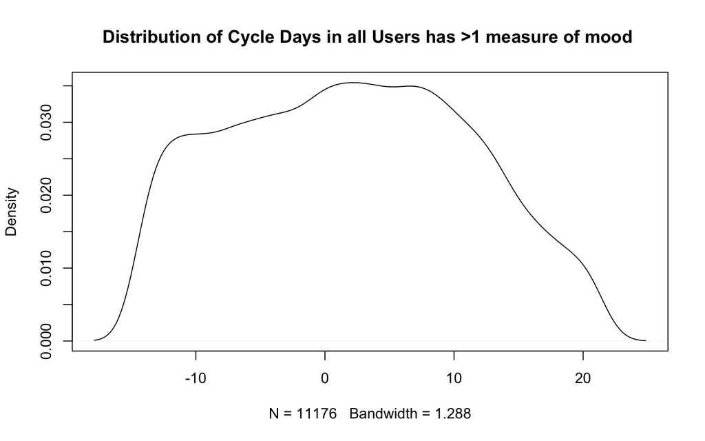

## Lower boundaries subsets

For reliability and validity, we explore two options of possible lower boundaries of inclusion criteria. This should ensure good distribution of data from each user across the cycle days.

```
We created a subset of users with
1. A miniumum of 5 observations
2. A minimum of 2 periods
```

Only performed on subsets with a minimum of 5 observations.

# Demographics

## Age of all avaliable data and subset of users with >5 recordings

Table of users by there age.

|  | Age.Range | Count |
| --- | --- | --- |
| 1 | 18-20 | 104 |
| 2 | 21-25 | 153 |
| 3 | 26-30 | 126 |
| 4 | 31-35 | 86 |
| 5 | 36-40 | 69 |
| 6 | 41-45 | 34 |
| 7 | 46+ | 21 |

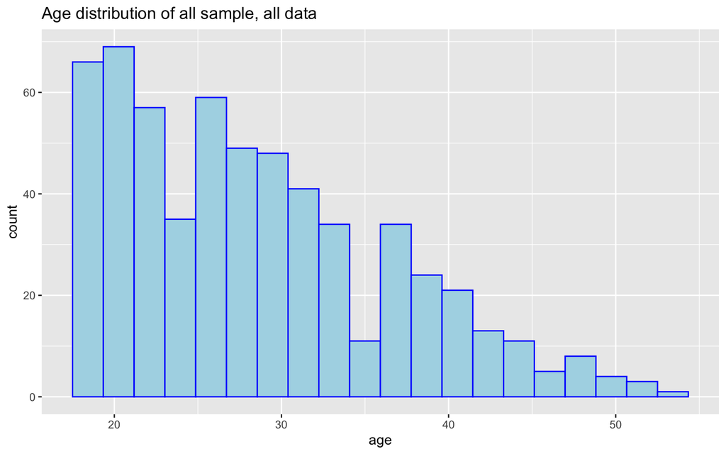

## Age of users in final data set

|  | Age.Range | Count |
| --- | --- | --- |
| 1 | 18-20 | 59 |
| 2 | 21-25 | 90 |
| 3 | 26-30 | 70 |
| 4 | 31-35 | 50 |
| 5 | 36-40 | 46 |
| 6 | 41-45 | 23 |
| 7 | 46+ | 14 |

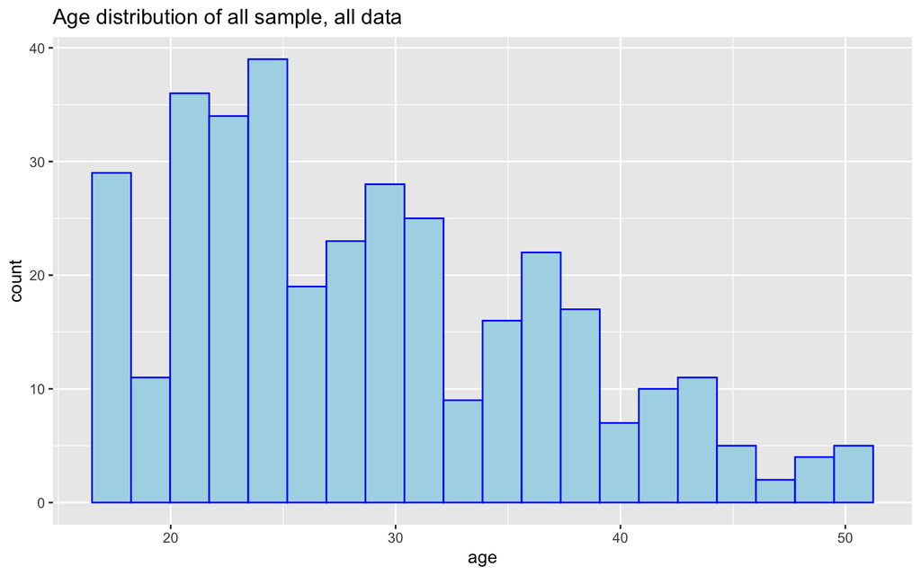

## Gender, All avaliable distribution

Individuals distribution

|  | Count | Percentage |
| --- | --- | --- |
| female | 553 | 0.9325464 |
| male | 3 | 0.0050590 |
| non-binary | 32 | 0.0539629 |
| transgender-man | 5 | 0.0084317 |

Overall Sample Representation

|  | Count | Percentage |
| --- | --- | --- |
| female | 10260 | 0.9180387 |
| male | 6 | 0.0005369 |
| non-binary | 742 | 0.0663923 |
| transgender-man | 168 | 0.0150322 |

## Gender, final model

Individuals distribution

|  | Count | Percentage |
| --- | --- | --- |
| female | 327 | 0.9289773 |
| non-binary | 21 | 0.0596591 |
| transgender-man | 4 | 0.0113636 |

Overall Sample Representation

|  | Count | Percentage |
| --- | --- | --- |
| female | 26998 | 0.9192686 |
| non-binary | 1946 | 0.0662603 |
| transgender-man | 425 | 0.0144710 |

## Ethnicity, all sample

A table and plot outlining the ethnicities in the sample

|  | Ethnicity | Number of Users in Sample |
| --- | --- | --- |
| 1 | american-indian-or-alaska-native | 3 |
| 2 | asian | 17 |
| 3 | black-or-african-american | 35 |
| 4 | native-hawaiian-or-other-pacific-islander | 2 |
| 5 | prefer-not-to-answer | 25 |
| 6 | Unknown | 285 |
| 7 | white | 226 |

## Ethnicity on subset of users in the final model

|  | Ethnicity | Number of Users in Sample |
| --- | --- | --- |
| 1 | asian | 10 |
| 2 | black-or-african-american | 17 |
| 3 | native-hawaiian-or-other-pacific-islander | 2 |
| 4 | prefer-not-to-answer | 12 |
| 5 | Unknown | 170 |
| 6 | white | 141 |

## PHQ Validation

Below is the output of a linear model showing there is a significant association between PHQ Score and the regular mood score that the users gave (p<0.004).

**Mood Score Validated by PHQ**

|  | *Dependent variable:* |
| --- | --- |
|  | PHQ Score |
|  | Mood |
| depr_bw_total | -0.037*** |
|  | (0.004) |
| Constant | 0.318*** |
|  | (0.055) |
| Observations | 1,382 |
| R<sup>2</sup> | 0.050 |
| Adjusted R<sup>2</sup> | 0.050 |
| Residual Std. Error | 1.012 (df = 1380) |
| F Statistic | 72.979*** (df = 1; 1380) |
| *Note:* | p<0.1; p<0.05; p<0.01 |

# Exploratory Analysis

A look at the mean values of mood score across different data sets.

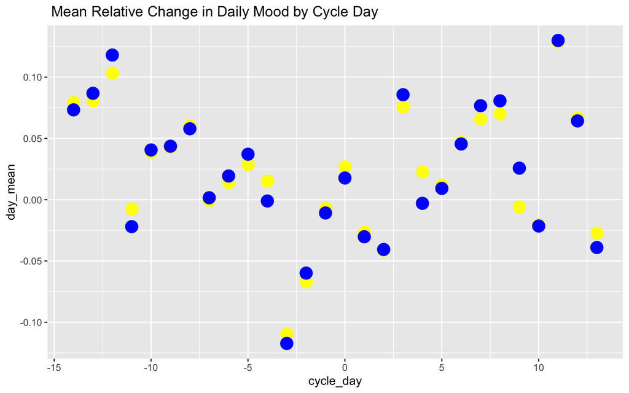

Yellow : All available data

Blue : Subset of those who logged >5 Days

# Models

After observing the shape of the data we ran modelling techniques to reflect this.

We will run regression models on all data sets, then see what is the entire data before running it on the lower bounded subset to run the final models on.

For a linear regression we a squared term to account for the curvature in trend in the data.

## All avaliable data

### All data: simple linear regression

$$y = Cycle Day + CycleDay^2 + c$$

|  | *Dependent variable:* |
| --- | --- |
|  | mood_relative |
| cycle_day | 0.0001 |
|  | (0.001) |
| daysq | 0.0004** |
|  | (0.0002) |
| Constant | -0.002 |
|  | (0.015) |
| Observations | 9,822 |
| R<sup>2</sup> | 0.001 |
| Adjusted R<sup>2</sup> | 0.0004 |
| Residual Std. Error | 0.990 (df = 9819) |
| F Statistic | 2.745* (df = 2; 9819) |
| *Note:* | p<0.1; p<0.05; p<0.01 |

### Multiple linear regression

Here we’ve added in the confounding variables available in the data set.

$$y = Cycle Day + CycleDay^2 + Age+ FindingDate + Gender + Step Count + c$$

|  | *Dependent variable:* |
| --- | --- |
|  | mood_relative |
| cycle_day | 0.0001 |
|  | (0.001) |
| daysq | 0.0004** |
|  | (0.0002) |
| ageatsignup | -0.0001 |
|  | (0.001) |
| findingdatetime | -0.0001 |
|  | (0.0001) |
| gendermale | -0.011 |
|  | (0.443) |
| gendernon-binary | 0.044 |
|  | (0.042) |
| gendertransgender-man | 0.042 |
|  | (0.083) |
| steps_count | 0.00001*** |
|  | (0.00000) |
| Constant | 1.449 |
|  | (1.161) |
| Observations | 9,530 |
| R<sup>2</sup> | 0.003 |
| Adjusted R<sup>2</sup> | 0.002 |
| Residual Std. Error | 0.990 (df = 9521) |
| F Statistic | 3.928*** (df = 8; 9521) |
| *Note:* | p<0.1; p<0.05; p<0.01 |

### General Additive Model

$$y = Smooth(Cycle Day)$$

```
##
## Call: gam(formula = mood_relative ~ s(cycle_day), data = juli_mood_28days)
## Deviance Residuals:
##      Min       1Q   Median       3Q      Max
## -4.78885 -0.56384  0.05771  0.66262  5.29603
##
## (Dispersion Parameter for gaussian family taken to be 0.979)
##
##     Null Deviance: 9620.091 on 9821 degrees of freedom
## Residual Deviance: 9610.73 on 9817 degrees of freedom
## AIC: 27672.05
##
## Number of Local Scoring Iterations: NA
##
## Anova for Parametric Effects
##                Df Sum Sq Mean Sq F value Pr(>F)
## s(cycle_day)    1    0.0 0.03701  0.0378 0.8459
## Residuals    9817 9610.7 0.97899
##
## Anova for Nonparametric Effects
##              Npar Df Npar F   Pr(F)
## (Intercept)
## s(cycle_day)       3 3.1748 0.02312 *
## ---
## Signif. codes:  0 '***' 0.001 '**' 0.01 '*' 0.05 '.' 0.1 ' ' 1
```

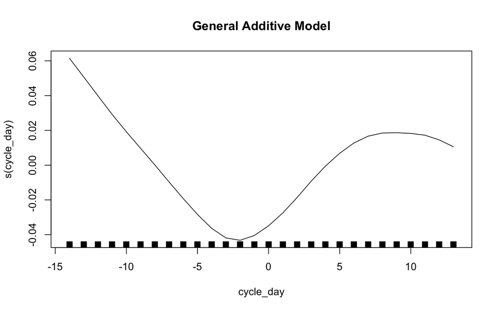

# Final Models (Users with 5+ days recorded)

### Simple Polynomial regression

$$y = Cycle Day + Cycle Day^2 + c$$

**Final Model**

|  | Users with >5 days entered |
| --- | --- |
|  | mood_relative |
|  | Relative Mood Score (Std Dvs) |
| cycle_day | 0.0003 |
|  | (0.001) |
| daysq | 0.0004** |
|  | (0.0002) |
| Constant | -0.004 |
|  | (0.015) |
| Observations | 9,346 |
| R<sup>2</sup> | 0.001 |
| Adjusted R<sup>2</sup> | 0.0004 |
| Residual Std. Error | 0.995 (df = 9343) |
| F Statistic | 2.958* (df = 2; 9343) |
| *Note:* | p<0.1; p<0.05; p<0.01 |

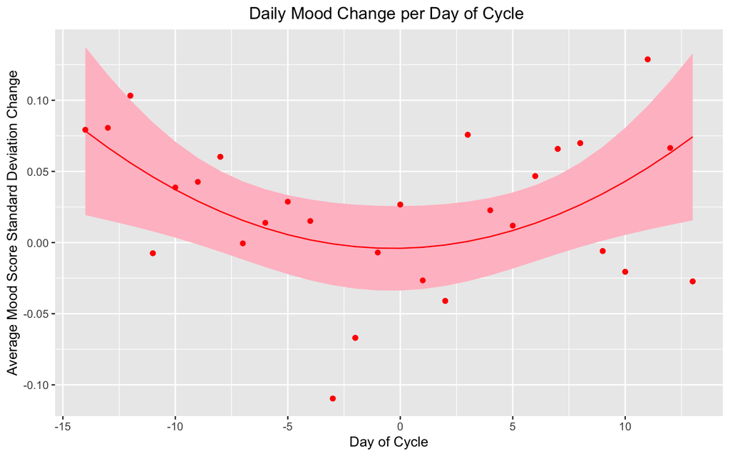

|  | Cycle Day | Expected Value | Lower Confidence Interval | Upper Confidence Interval |
| --- | --- | --- | --- | --- |
| 1 | -14 | 0.078 | 0.019 | 0.137 |
| 2 | -13 | 0.067 | 0.016 | 0.118 |
| 3 | -12 | 0.056 | 0.012 | 0.100 |
| 4 | -11 | 0.046 | 0.008 | 0.084 |
| 5 | -10 | 0.037 | 0.003 | 0.071 |
| 6 | -9 | 0.029 | -0.001 | 0.060 |
| 7 | -8 | 0.022 | -0.007 | 0.050 |
| 8 | -7 | 0.016 | -0.012 | 0.043 |
| 9 | -6 | 0.010 | -0.017 | 0.037 |
| 10 | -5 | 0.006 | -0.022 | 0.033 |
| 11 | -4 | 0.002 | -0.027 | 0.030 |
| 12 | -3 | -0.001 | -0.030 | 0.028 |
| 13 | -2 | -0.003 | -0.032 | 0.027 |
| 14 | -1 | -0.004 | -0.034 | 0.026 |
| 15 | 0 | -0.004 | -0.034 | 0.026 |
| 16 | 1 | -0.003 | -0.033 | 0.026 |
| 17 | 2 | -0.002 | -0.030 | 0.027 |
| 18 | 3 | 0.001 | -0.027 | 0.029 |
| 19 | 4 | 0.004 | -0.023 | 0.031 |
| 20 | 5 | 0.008 | -0.018 | 0.035 |
| 21 | 6 | 0.014 | -0.013 | 0.040 |
| 22 | 7 | 0.020 | -0.008 | 0.047 |
| 23 | 8 | 0.027 | -0.003 | 0.056 |
| 24 | 9 | 0.034 | 0.001 | 0.067 |
| 25 | 10 | 0.043 | 0.005 | 0.081 |
| 26 | 11 | 0.053 | 0.009 | 0.096 |
| 27 | 12 | 0.063 | 0.012 | 0.114 |
| 28 | 13 | 0.074 | 0.016 | 0.133 |

## Multiple Linear Regression with Co-founders

|  | *Dependent variable:* |
| --- | --- |
|  | mood_relative |
| cycle_day | 0.0003 |
|  | (0.001) |
| daysq | 0.0004** |
|  | (0.0002) |
| ageatsignup | -0.00001 |
|  | (0.001) |
| findingdatetime | -0.0001 |
|  | (0.0001) |
| gendernon-binary | 0.035 |
|  | (0.043) |
| gendertransgender-man | 0.047 |
|  | (0.084) |
| steps_count | 0.00001*** |
|  | (0.00000) |
| Constant | 1.775 |
|  | (1.197) |
| Observations | 9,070 |
| R<sup>2</sup> | 0.003 |
| Adjusted R<sup>2</sup> | 0.003 |
| Residual Std. Error | 0.995 (df = 9062) |
| F Statistic | 4.252*** (df = 7; 9062) |
| *Note:* | p<0.1; p<0.05; p<0.01 |

Final models with users with 5 or more days of observations. Plot with confidence intervals and daily change outputs presented, these are in terms of the change in standard deviations from the person’s mean value.

# Secondary Findings

### Relationship between HRV and Mood

$$Mood(Realtive) = HRV + Mood(Absolute) + c$$

```
Now we model the relationship between mood and HRV. We added in the absolute value of mood to scale the predictor.
There is a statistical linear relationship between the HRV and mood (p=0.005).
```

**HRV and Mood**

|  | *Dependent variable:* |
| --- | --- |
|  | mood_relative |
|  | Relative Mood Score (Std Dvs) |
| HRV | -0.001*** |
|  | (0.0005) |
| Mood (Non-Standardised | 0.594*** |
|  | (0.006) |
| Constant | -2.527*** |
|  | (0.032) |
| Observations | 4,847 |
| R<sup>2</sup> | 0.683 |
| Adjusted R<sup>2</sup> | 0.682 |
| Residual Std. Error | 0.557 (df = 4844) |
| F Statistic | 5,209.087*** (df = 2; 4844) |
| *Note:* | p<0.1; p<0.05; p<0.01 |

## Mood and HRV Displacement

Having observed the trends in the data, we want to explore if there is a delayed impact of the cycle on HRV.

### Relationship between Mood and HRV with displacement

Modelling the relationship between Mood and HRV from the previous day (minus 1), the day before that (minus 2) and the one before (minus 3).

$$Mood(Realtive) = HRVDayMinus1 + Mood (Absolute) + c$$

$$Mood(Realtive) = HRVDayMinus2 + Mood (Absolute) + c$$
$$Mood(Realtive) = HRVDayMinus3 + Mood (Absolute) + c$$

OLS linear model similarly significant relationship between day minus 1 (p=0.005), then minus 2 (p=0.005) and minus 3 days (p=0.005)

**HRV and Mood, with Day Displacement**

|  | Comparing different displacement Days |  |  |  |
| --- | --- | --- | --- | --- |
|  | mood_relative |  |  |  |
|  | Same Day | -1 Days | -2 Days | -3 Days |
|  | (1) | (2) | (3) | (4) |
| Same Day | -0.001*** |  |  |  |
|  | (0.0005) |  |  |  |
| -1 Days |  | -0.002*** |  |  |
|  |  | (0.0005) |  |  |
| -2 Days |  |  | -0.002*** |  |
|  |  |  | (0.0005) |  |
| -3 Days |  |  |  | -0.001*** |
|  |  |  |  | (0.0005) |
| Mood | 0.594*** | 0.595*** | 0.594*** | 0.599*** |
|  | (0.006) | (0.006) | (0.006) | (0.006) |
| Constant | -2.527*** | -2.520*** | -2.515*** | -2.544*** |
|  | (0.032) | (0.032) | (0.033) | (0.033) |
| Observations | 4,847 | 4,750 | 4,641 | 4,574 |
| R<sup>2</sup> | 0.683 | 0.686 | 0.685 | 0.684 |
| Adjusted R<sup>2</sup> | 0.682 | 0.686 | 0.685 | 0.684 |
| Residual Std. Error | 0.557 (df = 4844) | 0.553 (df = 4747) | 0.553 (df = 4638) | 0.558 (df = 4571) |
| F Statistic | 5,209.087*** (df = 2; 4844) | 5,194.513*** (df = 2; 4747) | 5,046.115*** (df = 2; 4638) | 4,943.501*** (df = 2; 4571) |
| *Note:* | p<0.1; p<0.05; p<0.01 |  |  |  |

|  | *Dependent variable:* |
| --- | --- |
|  | steps_count |
| cycle_day | -2.840 |
|  | (3.175) |
| Constant | 4,906.766*** |
|  | (24.881) |
| Observations | 24,420 |
| R<sup>2</sup> | 0.00003 |
| Adjusted R<sup>2</sup> | -0.00001 |
| Residual Std. Error | 3,883.237 (df = 24418) |
| F Statistic | 0.800 (df = 1; 24418) |
| *Note:* | p<0.1; p<0.05; p<0.01 |

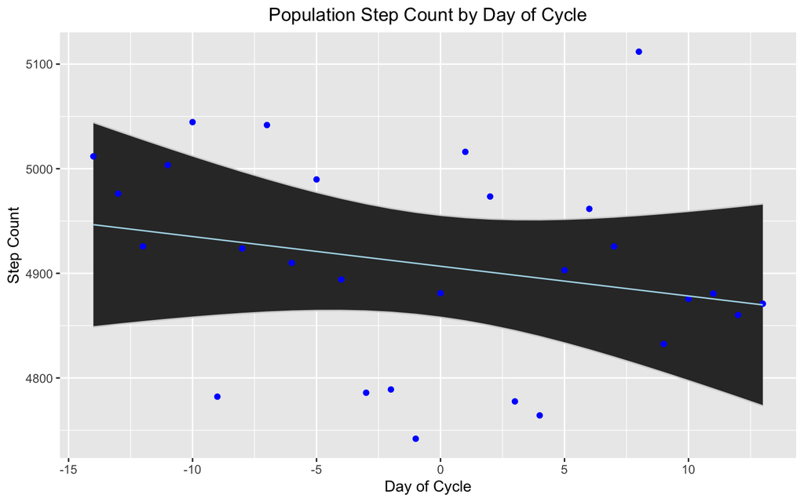

### Mood and step count

|  | *Dependent variable:* |
| --- | --- |
|  | steps_count |
| mood_relative | 188.062*** |
|  | (40.509) |
| Constant | 5,081.052*** |
|  | (40.359) |
| Observations | 9,070 |
| R<sup>2</sup> | 0.002 |
| Adjusted R<sup>2</sup> | 0.002 |
| Residual Std. Error | 3,842.787 (df = 9068) |
| F Statistic | 21.553*** (df = 1; 9068) |
| *Note:* | p<0.1; p<0.05; p<0.01 |

## Cycle Day and Energy

Exploring the relationship between recorded energy level and MC day.

There is no relationship between energy and day of cycle.

```
##
## Family: gaussian
## Link function: identity
##
## Formula:
## energy ~ s(cycle_day)
##
## Parametric coefficients:
##             Estimate Std. Error t value Pr(>|t|)
## (Intercept)  3.62330    0.01426     254   <2e-16 ***
## ---
## Signif. codes:  0 '***' 0.001 '**' 0.01 '*' 0.05 '.' 0.1 ' ' 1
##
## Approximate significance of smooth terms:
##              edf Ref.df     F p-value
## s(cycle_day)   1      1 2.225   0.136
##
## R-sq.(adj) =  0.00011   Deviance explained = 0.0199%
## GCV = 2.2743  Scale est. = 2.2739    n = 11176
```